# Untitled

Abhirup Sen

10/05/2021

```r
library(tidyverse)
library(MASS) # Boston data
library(ISLR) # Carseats data
library(randomForest) # random forests
library(tree) # trees
library(caret)
library(gridExtra)
library(gbm)
library(gam)
select <- dplyr::select

RNGkind(kind = "Mersenne-Twister",
        normal.kind = "Inversion",
        sample.kind = "Rejection") # diff versions of R/RMD using different sampling types was annoying me

# caret::train with RSS & MSE added:
custom_regression_metrics <- function (data, lev = NULL, model = NULL) {
  c(RMSE = sqrt(mean((data$obs-data$pred)^2)),
    Rsquared = summary(lm(pred ~ obs, data))$r.squared,
    MAE = mean(abs(data$obs-data$pred)),
    MSE = mean((data$obs-data$pred)^2),
    RSS = sum((data$obs-data$pred)^2))
}
```

Q: In the lab, we applied random forests to the Boston data using mtry = 6 and using ntree = 25 and ntree = 500. Create a plot displaying the test error resulting from random forests on this data set for a more comprehensive range of values for mtry and ntree. You can model your plot after Figure 8.10. Describe the results obtained.

```r
train_index <- sample(1:nrow(Boston), nrow(Boston) / 2)

train <- Boston[train_index, ]
test <- Boston[-train_index, ]
```

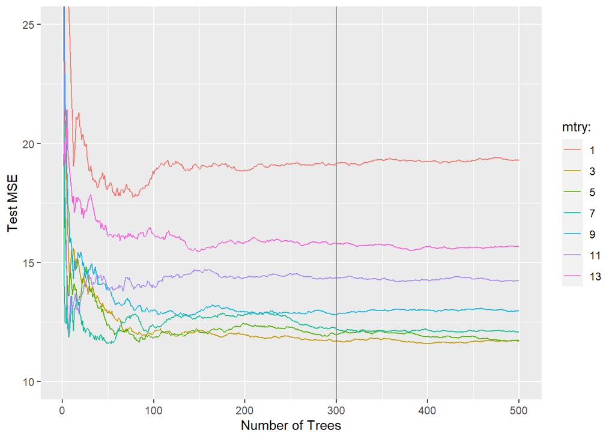

```r
test_MSE <- c()
OOB_MSE <- c()
mtry <- c()

i <- 1


set.seed(1)

for (Mtry in seq(1, 13, 2)) {

  rf_temp <- randomForest(y = train$medv,
                          x = train[ ,-14],
                          ytest = test$medv,
                          xtest = test[ ,-14],
                          mtry = Mtry,
                          ntree = 500)

  test_MSE[[i]] <- rf_temp$test$mse

  OOB_MSE[[i]] <- rf_temp$mse

  mtry[[i]] <- rep(Mtry, 500)

  i <- i + 1
}


rf_summary <- data.frame(ntree = rep(1:500, length(seq(1, 13, 2))),
                         mtry = unlist(mtry),
                         test_MSE = unlist(test_MSE),
                         OOB_MSE = unlist(OOB_MSE))


# test MSE:
ggplot(rf_summary, aes(x = ntree, y = test_MSE, col = factor(mtry))) +
  geom_line() +
  geom_vline(xintercept = 300, col = "grey55") +
  coord_cartesian(ylim = c(10, 25)) +
  labs(x = "Number of Trees",
       y = "Test MSE",
       col = "mtry:")
```

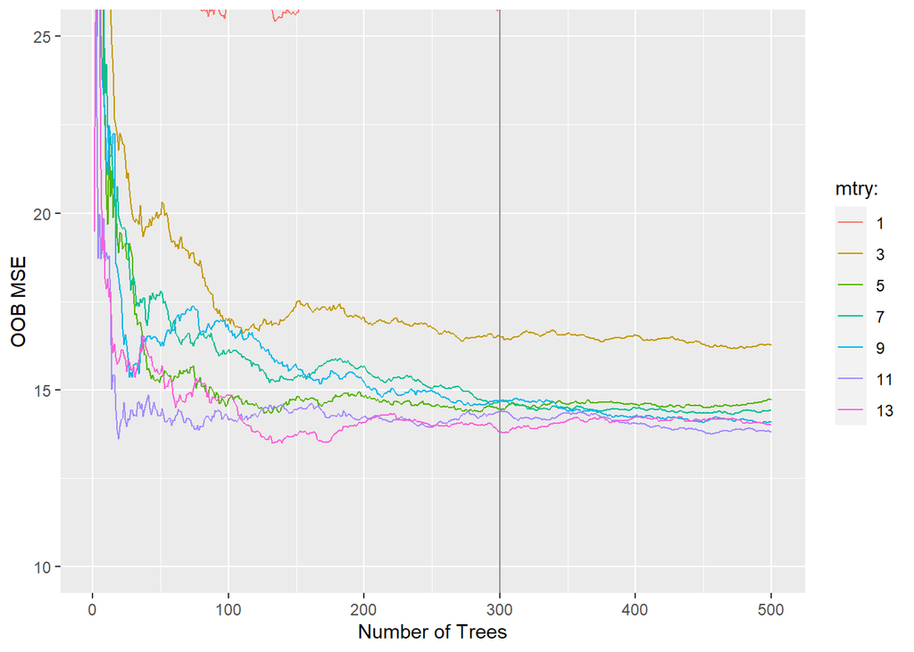

```r
# OOB MSE:
ggplot(rf_summary, aes(x = ntree, y = OOB_MSE, col = factor(mtry))) +
  geom_line() +
  geom_vline(xintercept = 300, col = "grey55") +
  coord_cartesian(ylim = c(10, 25)) +
  labs(x = "Number of Trees",
       y = "OOB MSE",
       col = "mtry:")
```

```r
set.seed(111)

rf_temp <- randomForest(y = train$medv,
                        x = train[ ,-14],
                        ntree = 500)

mean((500 - rf_temp$oob.times) / 500)
```

```
## [1] 0.6322609
```

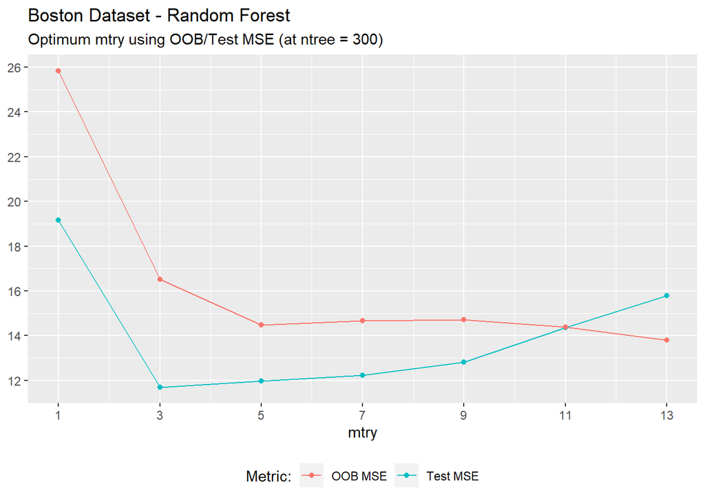

```r
rf_summary %>%
  filter(ntree == 300) %>%
  pivot_longer(cols = c(test_MSE, OOB_MSE), names_to = "metric") %>%
  ggplot(aes(x = mtry, y = value, col = factor(metric))) +
  geom_line() +
  geom_point() +
  scale_y_continuous(breaks = seq(10, 30, 2)) +
  scale_x_continuous(breaks = seq(1, 13, 2)) +
  scale_color_hue(labels = c("OOB MSE", "Test MSE")) +
  labs(col = "Metric:",
       title = "Boston Dataset - Random Forest",
       subtitle = "Optimum mtry using OOB/Test MSE (at ntree = 300)") +
  theme(legend.position = "bottom",
        axis.title.y = element_blank())
```

## Problem 8

**(a) train/test Split**

```r
set.seed(5)

train_index <- sample(1:nrow(OJ), 800)

train <- OJ[train_index, ]
test <- OJ[-train_index, ]
```

**(b) Classification Tree**

```r
tree_model <- tree(Purchase ~ ., train)

summary(tree_model)
```

```
##
## Classification tree:
## tree(formula = Purchase ~ ., data = train)
## Variables actually used in tree construction:
## [1] "LoyalCH"       "PriceDiff"     "ListPriceDiff"
## Number of terminal nodes:  9
## Residual mean deviance:  0.7347 = 581.1 / 791
## Misclassification error rate: 0.1662 = 133 / 800
```

** (c) tree() - Text Interpretation**

```r
tree_model
```

```
## node), split, n, deviance, yval, (yprob)
##       * denotes terminal node
##
##  1) root 800 1068.00 CH ( 0.61250 0.38750 )
##    2) LoyalCH < 0.5036 346  412.40 MM ( 0.28324 0.71676 )
##      4) LoyalCH < 0.280875 164  125.50 MM ( 0.12805 0.87195 )
##        8) LoyalCH < 0.0356415 56   10.03 MM ( 0.01786 0.98214 ) *
##        9) LoyalCH > 0.0356415 108  103.50 MM ( 0.18519 0.81481 ) *
##      5) LoyalCH > 0.280875 182  248.00 MM ( 0.42308 0.57692 )
##       10) PriceDiff < 0.05 71   67.60 MM ( 0.18310 0.81690 ) *
##       11) PriceDiff > 0.05 111  151.30 CH ( 0.57658 0.42342 ) *
##    3) LoyalCH > 0.5036 454  362.00 CH ( 0.86344 0.13656 )
##      6) PriceDiff < -0.39 31   40.32 MM ( 0.35484 0.64516 )
##       12) LoyalCH < 0.638841 10    0.00 MM ( 0.00000 1.00000 ) *
##       13) LoyalCH > 0.638841 21   29.06 CH ( 0.52381 0.47619 ) *
##      7) PriceDiff > -0.39 423  273.70 CH ( 0.90071 0.09929 )
##       14) LoyalCH < 0.705326 135  143.00 CH ( 0.77778 0.22222 )
##         28) ListPriceDiff < 0.255 67   89.49 CH ( 0.61194 0.38806 ) *
##         29) ListPriceDiff > 0.255 68   30.43 CH ( 0.94118 0.05882 ) *
##       15) LoyalCH > 0.705326 288   99.77 CH ( 0.95833 0.04167 ) *
```

```r
train %>%
  filter(LoyalCH < 0.5036,
         LoyalCH > 0.142213,
         PriceDiff > 0.235) %>%
  select(Purchase) %>%
  table()
```

```
## .
## CH MM
## 57 54
```

```r
-2 * (68 * log(68/118) + 50 * log(50/118))
```

```
## [1] 160.8262
```

**(d) Plotting** Q: Create a plot of the tree, and interpret the results.

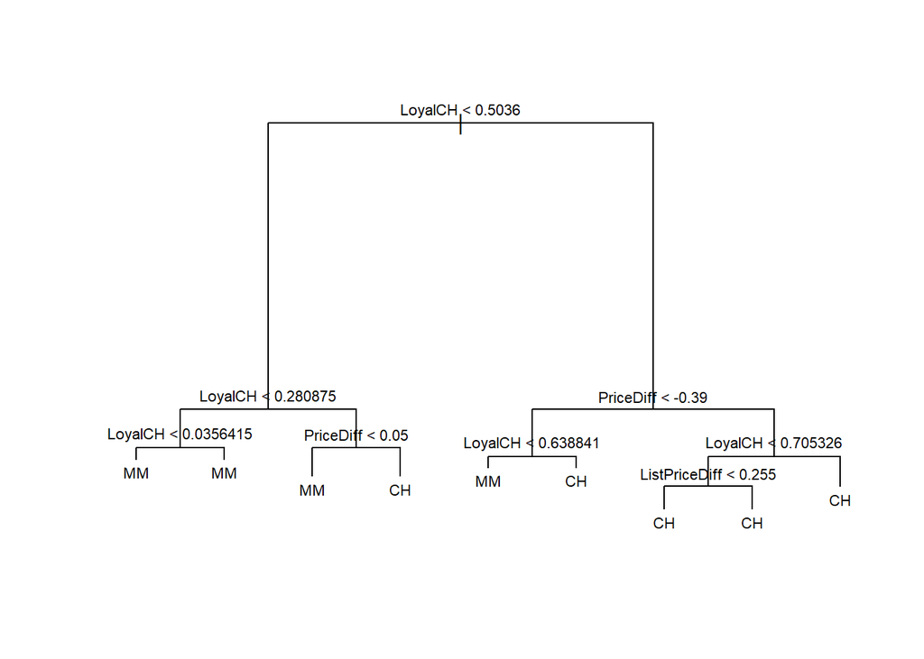

```r
plot(tree_model)
text(tree_model, pretty = 0, cex = 0.7)
```

**(e) Test Error**

```r
test_pred <- predict(tree_model, test, type = "class")
table(test_pred, test_actual = test$Purchase)
```

```
##          test_actual
## test_pred  CH  MM
##        CH 148  32
##        MM  15  75
```

The test error rate corresponding to it:

```r
1 - mean(test_pred == test$Purchase)
```

```
## [1] 0.1740741
```

```r
1 - mean(test$Purchase == "CH")
```

```
## [1] 0.3962963
```

**(f) Cost-Complexity Pruning**

```r
set.seed(2)

cv_tree_model <- cv.tree(tree_model, K = 10, FUN = prune.misclass)
cv_tree_model
```

```
## $size
## [1] 9 6 5 3 2 1
##
## $dev
## [1] 149 149 149 173 172 310
##
## $k
## [1]  -Inf   0.0   1.0   8.5   9.0 150.0
##
## $method
## [1] "misclass"
##
## attr(,"class")
## [1] "prune"         "tree.sequence"
```

**(g) CV Error Plot**

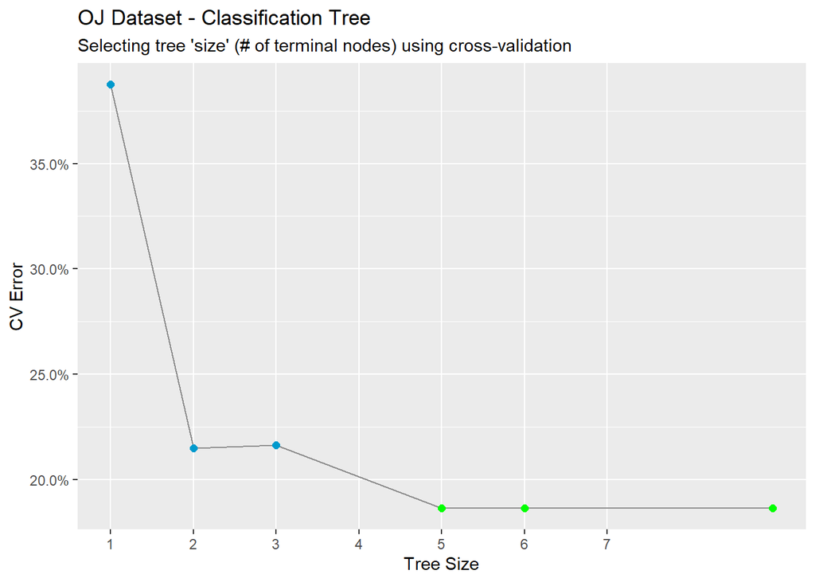

```r
data.frame(size = cv_tree_model$size, CV_Error = cv_tree_model$dev / nrow(train)) %>%
  mutate(min_CV_Error = as.numeric(min(CV_Error) == CV_Error)) %>%
  ggplot(aes(x = size, y = CV_Error)) +
  geom_line(col = "grey55") +
  geom_point(size = 2, aes(col = factor(min_CV_Error))) +
  scale_x_continuous(breaks = seq(1, 7), minor_breaks = NULL) +
  scale_y_continuous(labels = scales::percent_format()) +
  scale_color_manual(values = c("deepskyblue3", "green")) +
  theme(legend.position = "none") +
  labs(title = "OJ Dataset - Classification Tree",
       subtitle = "Selecting tree 'size' (# of terminal nodes) using cross-validation",
       x = "Tree Size",
       y = "CV Error")
```

**(i) Best Tree - Selecting**

```r
pruned_tree_model <- prune.tree(tree_model, best = 4)
pruned_tree_model
```

```
## node), split, n, deviance, yval, (yprob)
##       * denotes terminal node
##
## 1) root 800 1068.00 CH ( 0.61250 0.38750 )
##   2) LoyalCH < 0.5036 346  412.40 MM ( 0.28324 0.71676 )
##     4) LoyalCH < 0.280875 164  125.50 MM ( 0.12805 0.87195 ) *
##     5) LoyalCH > 0.280875 182  248.00 MM ( 0.42308 0.57692 ) *
##   3) LoyalCH > 0.5036 454  362.00 CH ( 0.86344 0.13656 )
##     6) PriceDiff < -0.39 31   40.32 MM ( 0.35484 0.64516 ) *
##     7) PriceDiff > -0.39 423  273.70 CH ( 0.90071 0.09929 ) *
```

**(j) Training Error Comparison**

```r
mean(predict(tree_model, type = "class") != train$Purchase)
```

```
## [1] 0.16625
```

The same for the pruned tree (4 terminal nodes):

```r
mean(predict(pruned_tree_model, type = "class") != train$Purchase)
```

```
## [1] 0.18875
```

The training error for the pruned tree is higher. The training error of a tree decreases as its flexibility (number of splits) increases.

**(k) Test Error Comparison** The test error for the unpruned tree:

```r
mean(predict(tree_model, type = "class", newdata = test) != test$Purchase)
```

```
## [1] 0.1740741
```

The same for the pruned tree:

```r
mean(predict(pruned_tree_model, type = "class", newdata = test) != test$Purchase)
```

```
## [1] 0.2
```

This might be because of the random variability when working with a small database. With a different random state for the CV folds and train/test split might change all of these results.

## Problem 10

```r
glimpse(Hitters)
```

```
## Rows: 322
## Columns: 20
## $ AtBat     <int> 293, 315, 479, 496, 321, 594, 185, 298, 323, 401, 574, 202, ~
## $ Hits      <int> 66, 81, 130, 141, 87, 169, 37, 73, 81, 92, 159, 53, 113, 60,~
## $ HmRun     <int> 1, 7, 18, 20, 10, 4, 1, 0, 6, 17, 21, 4, 13, 0, 7, 3, 20, 2,~
## $ Runs      <int> 30, 24, 66, 65, 39, 74, 23, 24, 26, 49, 107, 31, 48, 30, 29,~
## $ RBI       <int> 29, 38, 72, 78, 42, 51, 8, 24, 32, 66, 75, 26, 61, 11, 27, 1~
## $ Walks     <int> 14, 39, 76, 37, 30, 35, 21, 7, 8, 65, 59, 27, 47, 22, 30, 11~
## $ Years     <int> 1, 14, 3, 11, 2, 11, 2, 3, 2, 13, 10, 9, 4, 6, 13, 3, 15, 5,~
## $ CAtBat    <int> 293, 3449, 1624, 5628, 396, 4408, 214, 509, 341, 5206, 4631,~
## $ CHits     <int> 66, 835, 457, 1575, 101, 1133, 42, 108, 86, 1332, 1300, 467,~
## $ CHmRun    <int> 1, 69, 63, 225, 12, 19, 1, 0, 6, 253, 90, 15, 41, 4, 36, 3, ~
## $ CRuns     <int> 30, 321, 224, 828, 48, 501, 30, 41, 32, 784, 702, 192, 205, ~
## $ CRBI      <int> 29, 414, 266, 838, 46, 336, 9, 37, 34, 890, 504, 186, 204, 1~
## $ CWalks    <int> 14, 375, 263, 354, 33, 194, 24, 12, 8, 866, 488, 161, 203, 2~
## $ League    <fct> A, N, A, N, N, A, N, A, N, A, A, N, N, A, N, A, N, A, A, N, ~
## $ Division  <fct> E, W, W, E, E, W, E, W, W, E, E, W, E, E, E, W, W, W, W, W, ~
## $ PutOuts   <int> 446, 632, 880, 200, 805, 282, 76, 121, 143, 0, 238, 304, 211~
## $ Assists   <int> 33, 43, 82, 11, 40, 421, 127, 283, 290, 0, 445, 45, 11, 151,~
## $ Errors    <int> 20, 10, 14, 3, 4, 25, 7, 9, 19, 0, 22, 11, 7, 6, 8, 0, 10, 1~
## $ Salary    <dbl> NA, 475.000, 480.000, 500.000, 91.500, 750.000, 70.000, 100.~
## $ NewLeague <fct> A, N, A, N, N, A, A, A, N, A, A, N, N, A, N, A, N, A, A, N, ~
```

**Q: Remove the observations for whom the salary information is unknown, and then log-transform the salaries.**

```r
sum(is.na(Hitters$Salary))
```

```
## [1] 59
```

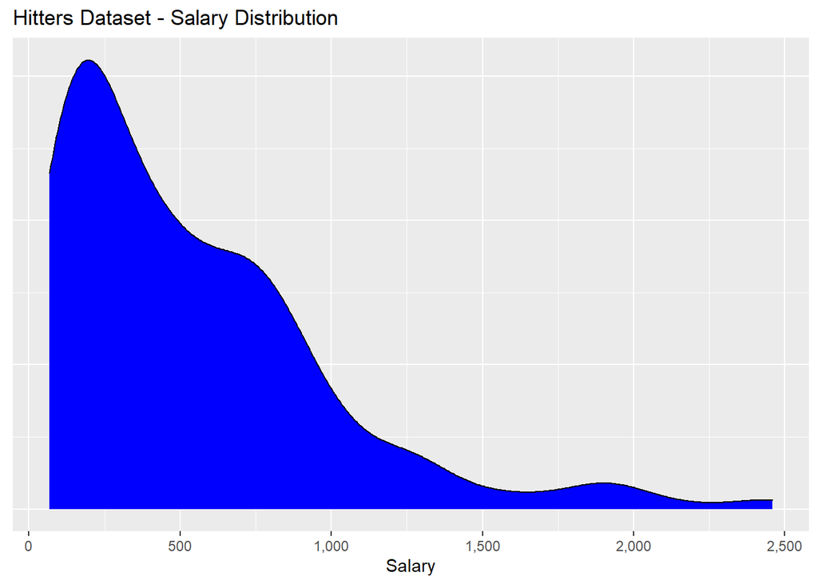

```r
Hitters_notNA <- Hitters[!is.na(Hitters$Salary), ]
Hitters_notNA$log_Salary <- log(Hitters_notNA$Salary)

ggplot(Hitters_notNA, aes(x = Salary)) +
  geom_density(fill = "blue") +
  scale_x_continuous(labels = scales::comma_format()) +
  theme(axis.text.y = element_blank(),
        axis.ticks.y = element_blank(),
        axis.title.y = element_blank()) +
  labs(title = "Hitters Dataset - Salary Distribution",
       x = "Salary")
```

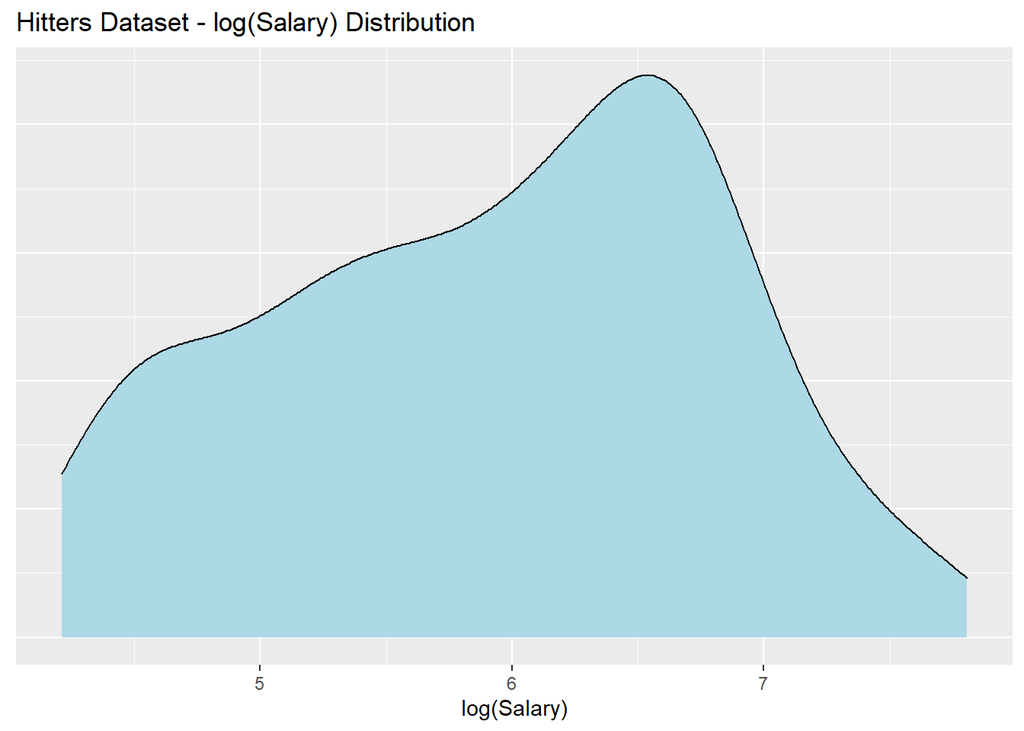

```r
ggplot(Hitters_notNA, aes(x = log_Salary)) +
  geom_density(fill = "lightblue") +
  theme(axis.text.y = element_blank(),
        axis.ticks.y = element_blank(),
        axis.title.y = element_blank()) +
  labs(title = "Hitters Dataset - log(Salary) Distribution",
       x = "log(Salary)")
```

**(b)Create a training set consisting of the first 200 observations, and a test set consisting of the remaining observations**

```r
train <- Hitters_notNA[1:200, ]
test <- Hitters_notNA[201:nrow(Hitters_notNA), ]
```

**(c) Perform boosting on the training set with 1,000 trees for a range of values of the shrinkage parameter λ. Produce a plot with different shrinkage values on the x-axis and the corresponding training set MSE on the y-axis.**

The performance metrics would be calculated on log_Salary.

The graph is displayed on a log10 scale. The training MSE decreases for higher values of λ.

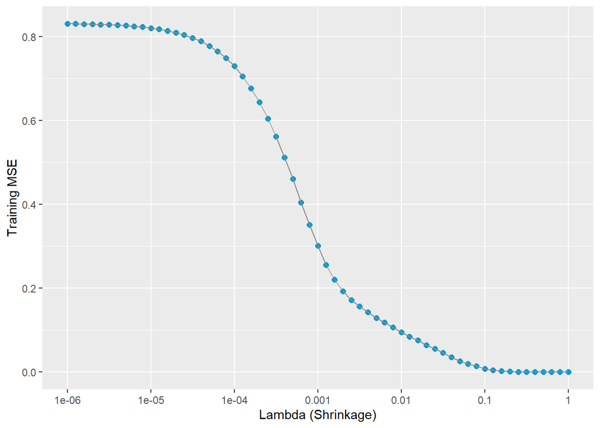

```r
lambda_seq <- 10^seq(-6, 0, 0.1)

set.seed(1)

train_MSE <- c()
test_MSE <- c()

for (i in 1:length(lambda_seq)) {
  boost_TEMP <- gbm(log_Salary ~ . - Salary,
                    data = train,
                    distribution = "gaussian",
                    n.trees = 1000,
                    interaction.depth = 2,
                    shrinkage = lambda_seq[i])

  train_MSE[i] <- mean((predict(boost_TEMP, train, n.trees = 1000) - train$log_Salary)^2)

  test_MSE[i] <- mean((predict(boost_TEMP, test, n.trees = 1000) - test$log_Salary)^2)
}

data.frame(lambda = lambda_seq, train_MSE) %>%
  ggplot(aes(x = lambda, y = train_MSE)) +
  geom_point(size = 2, col = "deepskyblue3") +
  geom_line(col = "grey55") +
  scale_x_continuous(trans = 'log10', breaks = 10^seq(-6, 0), labels = 10^seq(-6, 0), minor_breaks = NULL) +
  labs(x = "Lambda (Shrinkage)",
       y = "Training MSE")
```

**(d) Produce a plot with different shrinkage values on the x-axis and the corresponding test set MSE on the y-axis.**

using the same sequence of lambdas previously used.

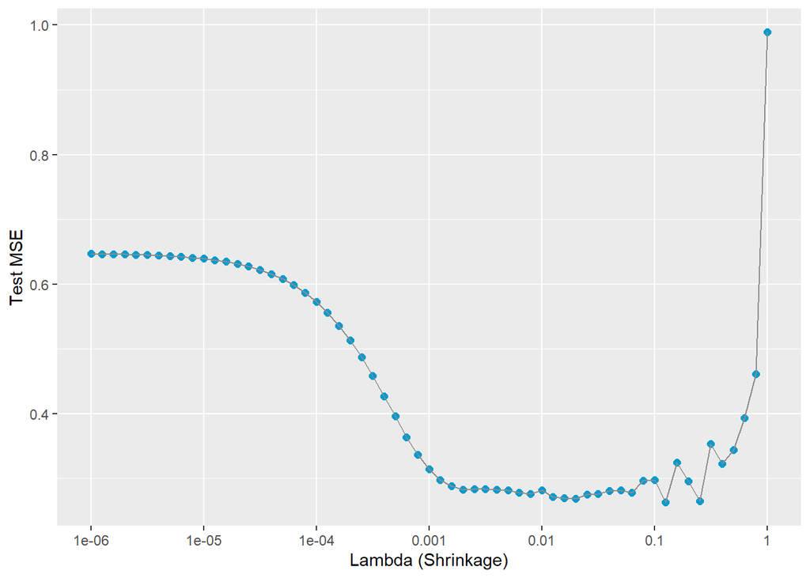

```r
data.frame(lambda = lambda_seq, test_MSE) %>%
  ggplot(aes(x = lambda, y = test_MSE)) +
  geom_point(size = 2, col = "deepskyblue3") +
  geom_line(col = "grey55") +
  scale_x_continuous(trans = 'log10', breaks = 10^seq(-6, 0), labels = 10^seq(-6, 0), minor_breaks = NULL) +
  labs(x = "Lambda (Shrinkage)",
       y = "Test MSE")
```

**(e) Compare the test MSE of boosting to the test MSE that results from applying two of the regression approaches seen in Chapters 3 and 6**

The 3 methods chosen are Boosting Partial Least Squares Regression Lasso Regression

**1. Boosting**

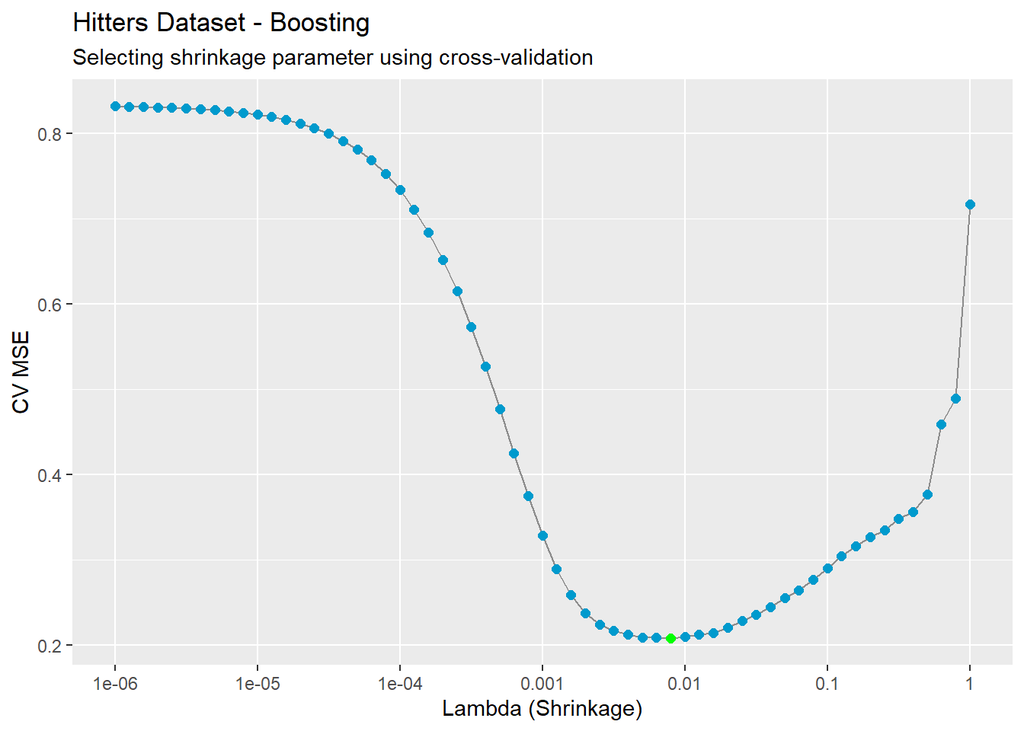

```r
set.seed(1)

ctrl <- trainControl(method = "repeatedcv", number = 5, repeats = 3, verboseIter = F, summaryFunction = custom_regression_metrics)

gbm_grid <- expand.grid(n.trees = 1000, interaction.depth = 2, n.minobsinnode = 10, shrinkage = 10^seq(-6, 0, 0.1))

model_gbm <- train(log_Salary ~ . - Salary,
                   data = train,
                   method = "gbm",
                   distribution = "gaussian",
                   verbose = F,
                   metric = "MSE",
                   maximize = F,
                   trControl = ctrl,
                   tuneGrid = gbm_grid)


model_gbm$results %>%
  rename(CV_MSE = MSE) %>%
  mutate(min_CV_MSE = as.numeric(shrinkage == model_gbm$bestTune$shrinkage)) %>%
  ggplot(aes(x = shrinkage, y = CV_MSE)) +
  geom_line(col = "grey55") +
  geom_point(size = 2, aes(col = factor(min_CV_MSE))) +
  scale_x_continuous(trans = 'log10', breaks = 10^seq(-6, 0), labels = 10^seq(-6, 0), minor_breaks = NULL) +
  scale_color_manual(values = c("deepskyblue3", "green")) +
  theme(legend.position = "none") +
  labs(title = "Hitters Dataset - Boosting",
       subtitle = "Selecting shrinkage parameter using cross-validation",
       x = "Lambda (Shrinkage)",
       y = "CV MSE")
```

The optimal value of shrinkage

```r
model_gbm$bestTune$shrinkage %>% round(4)
```

```
## [1] 0.0079
```

The corresponding cross-validation MSE:

```r
gbm_cv <- min(model_gbm$results$MSE) %>% round(4)
gbm_cv
```

```
## [1] 0.2078
```

The test MSE:

```r
gbm_test <- mean((predict(model_gbm, test) - test$log_Salary)^2) %>% round(4)
gbm_test
```

```
## [1] 0.2879
```

** 2. Partial Least Squares Regression**

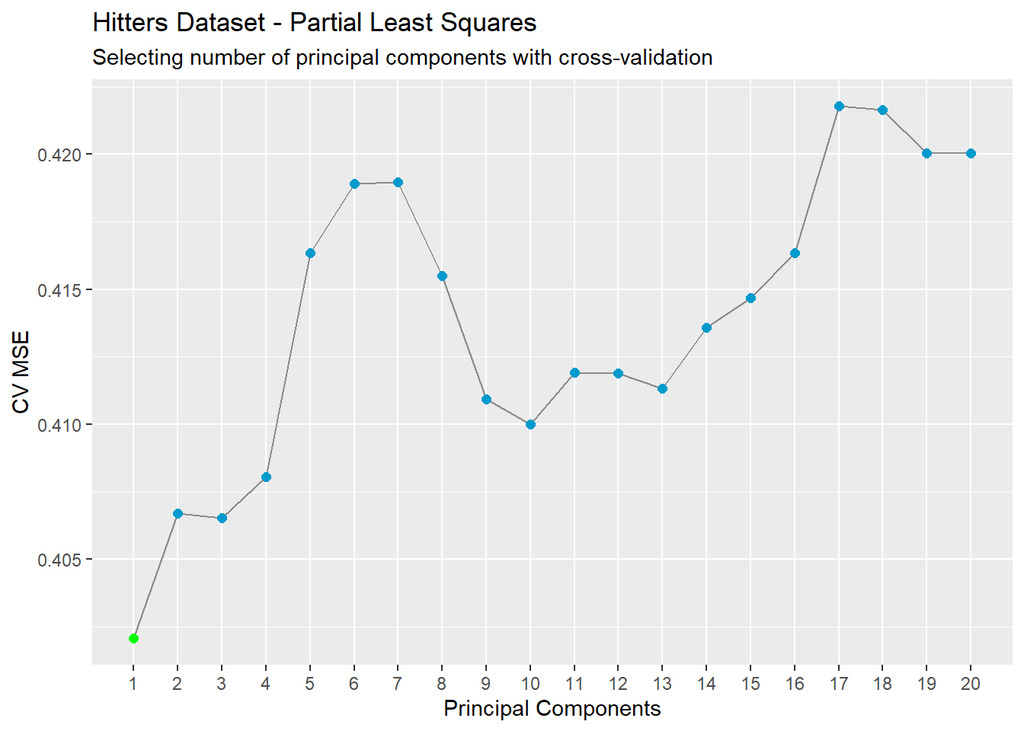

```r
set.seed(1)

ctrl <- trainControl(method = "repeatedcv", number = 5, repeats = 20, verboseIter = F, summaryFunction = custom_regression_metrics)

model_pls <- train(log_Salary ~ . - Salary,
                   data = train,
                   method = "pls",
                   preProcess = c("center", "scale"),
                   metric = "MSE",
                   maximize = F,
                   trControl = ctrl,
                   tuneGrid = data.frame(ncomp = 1:20))


model_pls$results %>%
  rename(CV_MSE = MSE) %>%
  mutate(min_CV_MSE = as.numeric(ncomp == model_pls$bestTune$ncomp)) %>%
  ggplot(aes(x = ncomp, y = CV_MSE)) +
  geom_line(col = "grey55") +
  geom_point(size = 2, aes(col = factor(min_CV_MSE))) +
  scale_x_continuous(breaks = 1:20, minor_breaks = NULL) +
  scale_color_manual(values = c("deepskyblue3", "green")) +
  theme(legend.position = "none") +
  labs(title = "Hitters Dataset - Partial Least Squares",
       subtitle = "Selecting number of principal components with cross-validation",
       x = "Principal Components",
       y = "CV MSE")
```

The optimal number of principal components:

```r
model_pls$bestTune$ncomp
```

```
## [1] 1
```

The corresponding cross-validation MSE:

```r
pls_cv <- min(model_pls$results$MSE) %>% round(4)
pls_cv
```

```
## [1] 0.4021
```

The test MSE:

```r
pls_test <- mean((predict(model_pls, test) - test$log_Salary)^2) %>% round(4)
pls_test
```

```
## [1] 0.466
```

** 3. Lasso Regression**

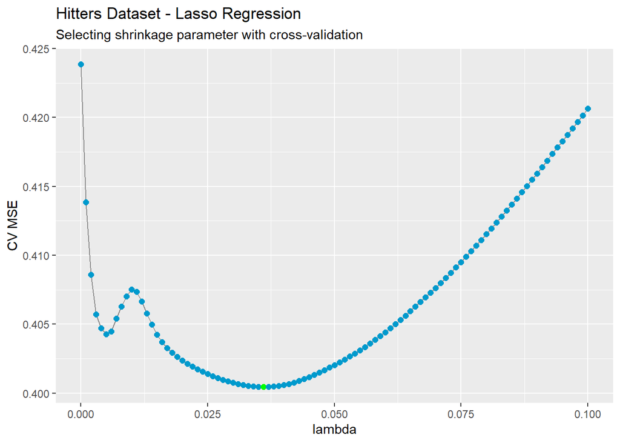

```r
ctrl <- trainControl(method = "repeatedcv", number = 5, repeats = 10, verboseIter = F, summaryFunction = custom_regression_metrics)

set.seed(1)

model_lasso <- train(log_Salary ~ . - Salary,
                   data = train,
                   method = "glmnet",
                   preProcess = c("center", "scale"),
                     metric = "MSE",
                     maximize = F,
                     trControl = ctrl,
                     tuneGrid = expand.grid(alpha = 1,
                                            lambda = seq(0, 0.1, 0.001)))



model_lasso$results %>%
  rename(CV_MSE = MSE) %>%
  mutate(min_CV_MSE = as.numeric(lambda == model_lasso$bestTune$lambda)) %>%
  ggplot(aes(x = lambda, y = CV_MSE)) +
  geom_line(col = "grey55") +
  geom_point(size = 2, aes(col = factor(min_CV_MSE))) +
  scale_color_manual(values = c("deepskyblue3", "green")) +
  theme(legend.position = "none") +
  labs(title = "Hitters Dataset - Lasso Regression",
       subtitle = "Selecting shrinkage parameter with cross-validation",
       y = "CV MSE")
```

The optimal value of lambda:

```r
model_lasso$bestTune$lambda
```

```
## [1] 0.036
```

The corresponding cross-validation MSE:

```r
lasso_cv <- min(model_lasso$results$MSE) %>% round(4)
lasso_cv
```

```
## [1] 0.4004
```

The test MSE:

```r
lasso_test <- mean((predict(model_lasso, test) - test$log_Salary)^2) %>% round(4)
lasso_test
```

```
## [1] 0.4546
```

The improvement in the test MSE for Boosting over the other (linear) regression approaches is noticeable.

**(f) Which variables appear to be the most important predictors in the boosted model?**

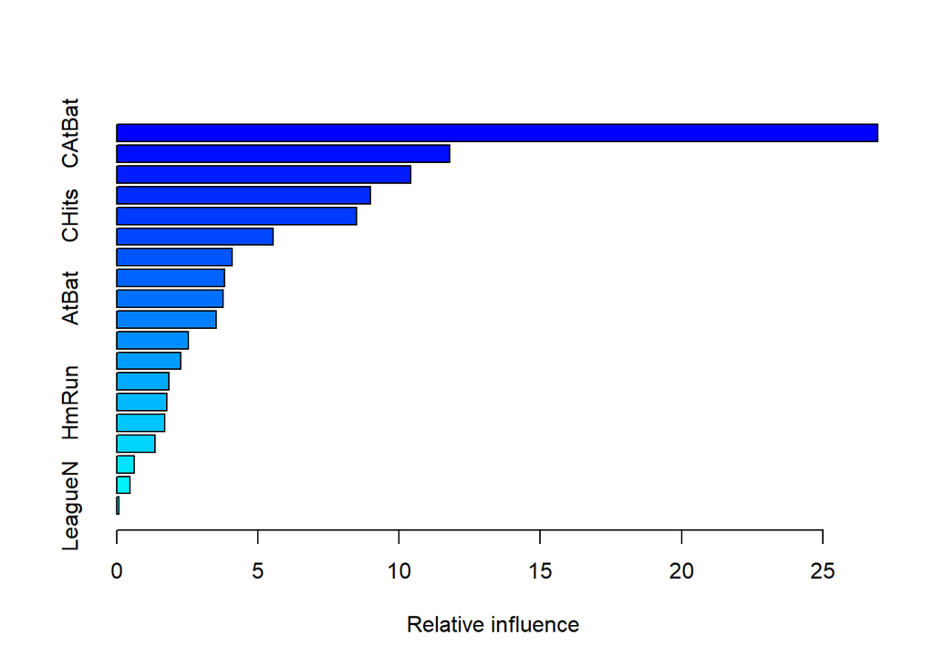

```
##                   var     rel.inf
## CAtBat         CAtBat 26.94426955
## CWalks         CWalks 11.79384094
## CRBI             CRBI 10.42210443
## CRuns           CRuns  8.99135715
## CHits           CHits  8.48182838
## Years           Years  5.55097097
## CHmRun         CHmRun  4.09954293
## Walks           Walks  3.81034530
## AtBat           AtBat  3.76508675
## PutOuts       PutOuts  3.51455034
## Assists       Assists  2.53694018
## RBI               RBI  2.25564532
## Hits             Hits  1.84021925
## HmRun           HmRun  1.77053992
## Errors         Errors  1.68975378
## Runs             Runs  1.36106826
## DivisionW   DivisionW  0.62181262
## NewLeagueN NewLeagueN  0.47272666
## LeagueN       LeagueN  0.07739728
```

```r
summary(model_gbm$finalModel)
```

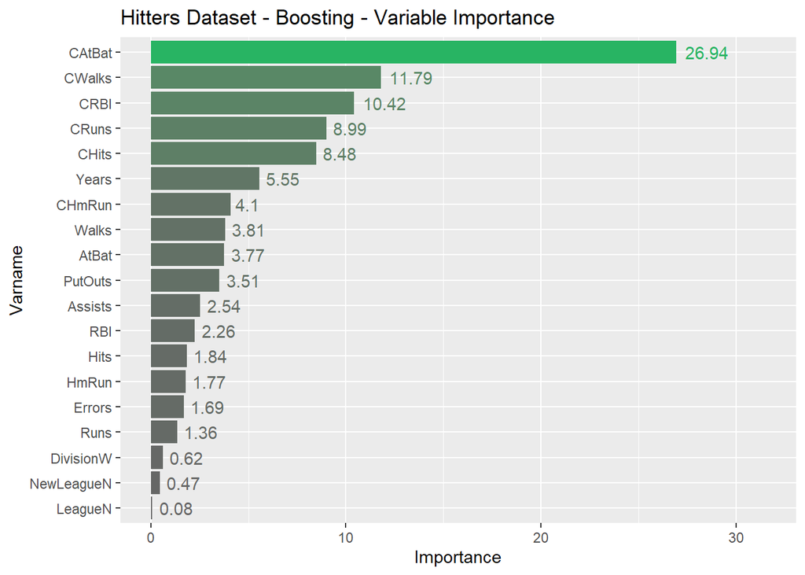

```r
# ggplot version:
summary(model_gbm$finalModel, plotit = F) %>%
  rename("Importance" = "rel.inf") %>%
  ggplot(aes(x = reorder(var, Importance), y = Importance, fill = Importance)) +
  geom_bar(stat = "identity") +
  geom_text(aes(label = round(Importance, 2), col = Importance), hjust = -0.2) +
  scale_y_continuous(limits = c(0, 31.5)) +
  scale_fill_gradient(low = "grey40", high = "#28B463") +
  scale_color_gradient(low = "grey40", high = "#28B463") +
  coord_flip() +
  theme(legend.position = "none") +
  labs(title = "Hitters Dataset - Boosting - Variable Importance",
       x = "Varname")
```

**(g) Now apply bagging to the training set. What is the test set MSE for this approach?**

```r
set.seed(1)

train_X <- select(train, -c(Salary, log_Salary))


ctrl <- trainControl(method = "repeatedcv", number = 5, repeats = 3, verboseIter = F, summaryFunction = custom_regression_metrics)

model_bagging <- train(y = train$log_Salary,
                   x = train_X,
                   method = "rf",
                   metric = "MSE",
                   maximize = F,
                   trControl = ctrl,
                   tuneGrid = expand.grid(mtry = 19))
```

The cross-validation MSE:

```r
bagging_cv <- model_bagging$results$MSE %>% round(4)
bagging_cv
```

```
## [1] 0.2246
```

The test MSE:

```r
bagging_test <- mean((predict(model_bagging, test) - test$log_Salary)^2) %>% round(4)
bagging_test
```

```
## [1] 0.2381
```

To summarize

```r
data.frame(method = c("Boosting", "PLS", "Lasso", "Bagging"),
           CV_MSE = c(gbm_cv, pls_cv, lasso_cv, bagging_cv),
           test_MSE = c(gbm_test, pls_test, lasso_test, bagging_test)) %>%
  arrange(test_MSE)
```

```
##     method CV_MSE test_MSE
## 1  Bagging 0.2246   0.2381
## 2 Boosting 0.2078   0.2879
## 3    Lasso 0.4004   0.4546
## 4      PLS 0.4021   0.4660
```

Though the dataset size is small, bagging performed slightly better than boosting.

## Problem 11

```r
glimpse(Caravan)
```

```
## Rows: 5,822
## Columns: 86
## $ MOSTYPE  <dbl> 33, 37, 37, 9, 40, 23, 39, 33, 33, 11, 10, 9, 33, 41, 23, 33,~
## $ MAANTHUI <dbl> 1, 1, 1, 1, 1, 1, 2, 1, 1, 2, 1, 1, 1, 1, 1, 1, 1, 2, 1, 1, 1~
## $ MGEMOMV  <dbl> 3, 2, 2, 3, 4, 2, 3, 2, 2, 3, 4, 3, 2, 3, 1, 2, 2, 3, 4, 2, 4~
## $ MGEMLEEF <dbl> 2, 2, 2, 3, 2, 1, 2, 3, 4, 3, 3, 3, 3, 3, 2, 3, 3, 3, 2, 4, 3~
## $ MOSHOOFD <dbl> 8, 8, 8, 3, 10, 5, 9, 8, 8, 3, 3, 3, 8, 10, 5, 8, 9, 5, 3, 7,~
## $ MGODRK   <dbl> 0, 1, 0, 2, 1, 0, 2, 0, 0, 3, 1, 1, 1, 0, 0, 0, 0, 0, 2, 0, 0~
## $ MGODPR   <dbl> 5, 4, 4, 3, 4, 5, 2, 7, 1, 5, 4, 3, 4, 5, 6, 7, 6, 5, 4, 2, 6~
## $ MGODOV   <dbl> 1, 1, 2, 2, 1, 0, 0, 0, 3, 0, 1, 2, 1, 0, 1, 0, 0, 0, 0, 0, 0~
## $ MGODGE   <dbl> 3, 4, 4, 4, 4, 5, 5, 2, 6, 2, 4, 4, 4, 4, 2, 2, 3, 4, 3, 7, 3~
## $ MRELGE   <dbl> 7, 6, 3, 5, 7, 0, 7, 7, 6, 7, 7, 7, 6, 7, 1, 7, 7, 7, 7, 9, 9~
## $ MRELSA   <dbl> 0, 2, 2, 2, 1, 6, 2, 2, 0, 0, 1, 1, 2, 1, 2, 2, 0, 0, 0, 0, 0~
## $ MRELOV   <dbl> 2, 2, 4, 2, 2, 3, 0, 0, 3, 2, 2, 2, 3, 1, 6, 0, 2, 2, 2, 0, 0~
## $ MFALLEEN <dbl> 1, 0, 4, 2, 2, 3, 0, 0, 3, 2, 0, 2, 3, 1, 5, 0, 0, 0, 1, 0, 0~
```

[output cut: 73 more lines]

**(a) Create a training set consisting of the first 1,000 observations, and a test set consisting of the remaining observations.**

```r
train <- Caravan[1:1000, ]
test <- Caravan[1001:nrow(Caravan), ]

nrow(train)
```

```
## [1] 1000
```

```r
nrow(test)
```

```
## [1] 4822
```

**(b) Fit a boosting model to the training set with Purchase as the response and the other variables as predictors. Use 1,000 trees, and a shrinkage value of 0.01. Which predictors appear to be the most important?**

with $interaction.depth = 2$ and $n.minobsinnode = 10$

```r
names(train)
```

```
##  [1] "MOSTYPE"  "MAANTHUI" "MGEMOMV"  "MGEMLEEF" "MOSHOOFD" "MGODRK"
##  [7] "MGODPR"   "MGODOV"   "MGODGE"   "MRELGE"   "MRELSA"   "MRELOV"
## [13] "MFALLEEN" "MFGEKIND" "MFWEKIND" "MOPLHOOG" "MOPLMIDD" "MOPLLAAG"
## [19] "MBERHOOG" "MBERZELF" "MBERBOER" "MBERMIDD" "MBERARBG" "MBERARBO"
## [25] "MSKA"     "MSKB1"    "MSKB2"    "MSKC"     "MSKD"     "MHHUUR"
## [31] "MHKOOP"   "MAUT1"    "MAUT2"    "MAUT0"    "MZFONDS"  "MZPART"
## [37] "MINKM30"  "MINK3045" "MINK4575" "MINK7512" "MINK123M" "MINKGEM"
## [43] "MKOOPKLA" "PWAPART"  "PWABEDR"  "PWALAND"  "PPERSAUT" "PBESAUT"
## [49] "PMOTSCO"  "PVRAAUT"  "PAANHANG" "PTRACTOR" "PWERKT"   "PBROM"
## [55] "PLEVEN"   "PPERSONG" "PGEZONG"  "PWAOREG"  "PBRAND"   "PZEILPL"
## [61] "PPLEZIER" "PFIETS"   "PINBOED"  "PBYSTAND" "AWAPART"  "AWABEDR"
## [67] "AWALAND"  "APERSAUT" "ABESAUT"  "AMOTSCO"  "AVRAAUT"  "AAANHANG"
## [73] "ATRACTOR" "AWERKT"   "ABROM"    "ALEVEN"   "APERSONG" "AGEZONG"
## [79] "AWAOREG"  "ABRAND"   "AZEILPL"  "APLEZIER" "AFIETS"   "AINBOED"
## [85] "ABYSTAND" "Purchase"
```

```r
nearZeroVar(train["AVRAAUT"], saveMetrics = TRUE)
```

```
##         freqRatio percentUnique zeroVar  nzv
## AVRAAUT         0           0.1    TRUE TRUE
```

```r
nearZeroVar(train["PVRAAUT"], saveMetrics = TRUE)
```

```
##         freqRatio percentUnique zeroVar  nzv
## PVRAAUT         0           0.1    TRUE TRUE
```

```r
table(AVRAAUT = train$AVRAAUT)
```

```
## AVRAAUT
##    0
## 1000
```

```r
table(PVRAAUT = train$PVRAAUT)
```

```
## PVRAAUT
##    0
## 1000
```

```r
table(AZEILPL = train$AZEILPL)
```

```
## AZEILPL
##   0   1
## 999   1
```

```r
train <- Caravan[1:1000, ]
test <- Caravan[1001:nrow(Caravan), ]

nrow(train)
```

```
## [1] 1000
```

```r
nrow(test)
```

```
## [1] 4822
```

```r
gbm_grid <- expand.grid(n.trees = 1000, shrinkage = 0.01,
                        interaction.depth = 2, n.minobsinnode = 10)

set.seed(5)

model_gbm <- train(Purchase ~ .,
                   data = train,
                   method = "gbm",
                   distribution = "bernoulli",
                   verbose = F,
                   trControl = trainControl(method = "none", summaryFunction = defaultSummary, classProbs = T),
                   tuneGrid = gbm_grid)
```

[figure not shown]

```r
gbm_importance <- summary(model_gbm$finalModel, plotit = F) %>%
  rename("Importance" = "rel.inf")

gbm_importance %>%
  filter(Importance > 0) %>%
  ggplot(aes(x = reorder(var, Importance), y = Importance, fill = Importance)) +
  geom_bar(stat = "identity") +
  geom_text(aes(label = round(Importance, 2), col = Importance), hjust = -0.2) +
  scale_y_continuous(limits = c(0, 10.5)) +
  scale_fill_gradient(low = "grey40", high = "#28B463") +
  scale_color_gradient(low = "grey40", high = "#28B463") +
  coord_flip() +
  theme(legend.position = "none") +
  labs(title = "Caravan Dataset - Boosting - Variable Importance",
       subtitle = paste0(sum(gbm_importance$Importance == 0), " zero-importance variables removed"),
       x = "Varname")
```

**(c) Use the boosting model to predict the response on the test data. Predict that a person will make a purchase if the estimated probability of purchase is greater than 20%. Form a confusion matrix. What fraction of the people predicted to make a purchase do in fact make one? How does this compare with the results obtained from applying KNN or logistic regression to this dataset?**

```r
custom_precision <- function (data, lev = NULL, model = NULL){
  actual <- data[ ,"obs"]
  probs <- data[ ,"Yes"]
  predicted <- factor(ifelse(probs > 0.2, "Yes", "No")) # most important line
  levels(actual) <- c("No", "Yes")
  levels(predicted) <- c("No", "Yes")
  out <- caret::precision(data = predicted, reference = actual, relevant = "Yes")
  names(out) <- c("Precision [thresh = 0.2]")
  out
}
```

**Boosting:**

```r
gbm_grid <- expand.grid(n.trees = 1000, shrinkage = 0.01,
                        interaction.depth = 2, n.minobsinnode = 10)

ctrl <- trainControl(method = "repeatedcv", number = 5, repeats = 3, summaryFunction = custom_precision, classProbs = T)

set.seed(5)

model_gbm <- train(Purchase ~ .,
                   data = train,
                   method = "gbm",
                   distribution = "bernoulli",
                   verbose = F,
                   metric = "Precision [thresh = 0.2]",
                   maximize = T,
                   trControl = ctrl,
                   tuneGrid = gbm_grid)
```

The cross-validation precision:

```r
model_gbm$results$`Precision [thresh = 0.2]` %>% round(4)
```

```
## [1] 0.1788
```

Confusion matrix for $test$

```r
predicted <- factor(ifelse(predict(model_gbm, test, "prob")$Yes > 0.2, "Yes", "No")) %>% relevel(ref = "Yes")
actual <- test$Purchase %>% relevel(ref = "Yes")

conf_matrix <- table(predicted, actual)
conf_matrix
```

```
##          actual
## predicted  Yes   No
##       Yes   36  173
##       No   253 4360
```

```r
 # precision = TP / (TP + FP)

precision <- conf_matrix[1, 1] / (conf_matrix[1, 1] + conf_matrix[1, 2])
precision %>% round(4)
```

```
## [1] 0.1722
```

**KNN**

```r
set.seed(5)

model_knn <- train(Purchase ~ .,
                   data = train,
                   method = "knn",
                   preProcess = c("center", "scale"),
                   trControl = trainControl(method = "repeatedcv", number = 5, repeats = 10, summaryFunction = custom_precision, classProbs = T, returnResamp = "all"),
                   metric = "Precision [thresh = 0.2]",
                   maximize = T,
                   tuneGrid = expand.grid(k = seq(1, 45, 2)))
```

[output not shown]

[output cut: 13 more lines]

[output not shown]

[output not shown]

[output cut: 13 more lines]

[output not shown]

[output not shown]

[output cut: 13 more lines]

[output not shown]

[output not shown]

[output cut: 13 more lines]

[output not shown]

[output not shown]

[output cut: 13 more lines]

[output not shown]

[output not shown]

[output cut: 13 more lines]

[output not shown]

[output not shown]

[output cut: 36 more lines]

[output not shown]

[output not shown]

[output cut: 13 more lines]

[output not shown]

[output not shown]

[output cut: 13 more lines]

[output not shown]

[output not shown]

[output cut: 13 more lines]

[output not shown]

[output not shown]

[output cut: 13 more lines]

[output not shown]

[output not shown]

[output cut: 13 more lines]

[output not shown]

[output not shown]

[output cut: 13 more lines]

[output not shown]

[output not shown]

[output cut: 13 more lines]

[output not shown]

[output not shown]

[output cut: 13 more lines]

[output not shown]

[output not shown]

[output cut: 13 more lines]

[output not shown]

[output not shown]

[output cut: 13 more lines]

[output not shown]

[output not shown]

[output cut: 13 more lines]

[output not shown]

[output not shown]

[output cut: 13 more lines]

[output not shown]

[output not shown]

[output cut: 13 more lines]

[output not shown]

[output not shown]

[output cut: 13 more lines]

[output not shown]

[output not shown]

[output cut: 13 more lines]

[output not shown]

[output not shown]

[output cut: 13 more lines]

[output not shown]

[output not shown]

[output cut: 13 more lines]

[output not shown]

[output not shown]

[output cut: 13 more lines]

[output not shown]

[output not shown]

[output cut: 13 more lines]

[output not shown]

[output not shown]

[output cut: 13 more lines]

[output not shown]

[output not shown]

[output cut: 13 more lines]

[output not shown]

[output not shown]

[output cut: 13 more lines]

[output not shown]

[output not shown]

[output cut: 13 more lines]

[output not shown]

[output not shown]

[output cut: 13 more lines]

[output not shown]

[output not shown]

[output cut: 13 more lines]

[output not shown]

[output not shown]

[output cut: 13 more lines]

[output not shown]

[output not shown]

[output cut: 13 more lines]

[output not shown]